# examen_real_2022

Laura Ibarra

31/1/2022

# Examen Bioinformatica

### Ejercicio 1 - LInux

1. ¿Cuantas palabra hay en el fichero? cat genes.txt | wc
2. ¿Cómo cambiarías todos los tabulados por guiones ? cat genes.txt | sed s’/-/g’
3. ¿Cómo cambiarías solo la primera aparición? cat genes.txt | sed s’/g/G/’
4. ¿Cómo buscarías todos los genes excepto el llamado DSTYK? cat genes.txt | grep -v ‘DSTYK’

### Ejercicio 2 - Rstudio

```r
library(nycflights13)
library(tidyverse)
weather <- nycflights13::weather
```

2.a ¿Cuántas columnas y cuántos registros tiene este dataset?

```r
ncol(weather)
```

```
## [1] 15
```

```r
nrow(weather)
```

```
## [1] 26115
```

2.b ¿Cuántos “origin” diferentes existen y para cada uno de ellos cuántos registros hay?

```r
table(weather$origin)
```

```
##
##  EWR  JFK  LGA
## 8703 8706 8706
```

2.c En LGA, ¿cuáles fueron la mediana del wind_speed y media de pressure?

```r
LGA <- weather[weather$origin == "LGA",]
median(LGA$wind_speed, na.rm = T)
```

```
## [1] 10.35702
```

```r
mean(LGA$pressure, na.rm = T)
```

```
## [1] 1017.678
```

2.d Después de eliminar los NA de la columna wind_gust, calcula para cada mes la media de wind_speed y wind_gust, y el número de casos.

```r
library(dplyr)
weather1<- mutate_at(weather, "wind_gust", ~replace(., is.na(.), 0))

#Para cada mes
mes1 <- weather1[weather1$month == 1,]
mes2 <- weather1[weather1$month == 2,]
mes3 <- weather1[weather1$month == 3,]
mes4 <- weather1[weather1$month == 4,]
mes5 <- weather1[weather1$month == 5,]
mes6 <- weather1[weather1$month == 6,]
mes7 <- weather1[weather1$month == 7,]
mes8 <- weather1[weather1$month == 8,]
mes9 <- weather1[weather1$month == 9,]
mes10 <- weather1[weather1$month == 10,]
mes11 <- weather1[weather1$month == 11,]
mes12 <- weather1[weather1$month == 12,]

media_wind_gust <- function(data)
{
  mean(data$wind_gust, na.rm = T)
}

media_wind_speed <- function(data)
{
  mean(data$wind_speed, na.rm = T)
}

num_casos <- function(data)
{
  nrow(data)
}

medias <- function(data)
{
  a <- num_casos(data)
  b <- media_wind_gust(data)
  c <- media_wind_speed(data)
  print(paste0("casos:",a," ","wind_gust:",b, " ","wind_speed:", c))
}

medias(mes12)
```

```
## [1] "casos:2144 wind_gust:3.71212429104478 wind_speed:10.1310506063433"
```

```r
medias(mes11)
```

```
## [1] "casos:2141 wind_gust:8.02159772069126 wind_speed:11.8018105838393"
```

```r
medias(mes10)
```

```
## [1] "casos:2212 wind_gust:3.64118861663653 wind_speed:9.70203264918626"
```

```r
medias(mes9)
```

```
## [1] "casos:2159 wind_gust:2.7370334877258 wind_speed:8.906685409912"
```

```r
medias(mes8)
```

```
## [1] "casos:2217 wind_gust:2.18528813712224 wind_speed:8.61190391520072"
```

```r
medias(mes7)
```

```
## [1] "casos:2228 wind_gust:2.42965400359066 wind_speed:9.58207875112309"
```

```r
medias(mes6)
```

```
## [1] "casos:2160 wind_gust:4.71606692592593 wind_speed:10.2632527407407"
```

```r
medias(mes5)
```

```
## [1] "casos:2232 wind_gust:3.94575239247312 wind_speed:9.52088625728373"
```

```r
medias(mes4)
```

```
## [1] "casos:2159 wind_gust:6.89242064844836 wind_speed:11.0984442612321"
```

```r
medias(mes3)
```

```
## [1] "casos:2227 wind_gust:9.36487918275707 wind_speed:12.9289564330638"
```

```r
medias(mes2)
```

```
## [1] "casos:2010 wind_gust:8.57302473631841 wind_speed:12.674038238806"
```

```r
medias(mes1)
```

```
## [1] "casos:2226 wind_gust:6.60742101527403 wind_speed:11.1836584636119"
```

### Ejercicio 3

3.a Crea el plot anterior

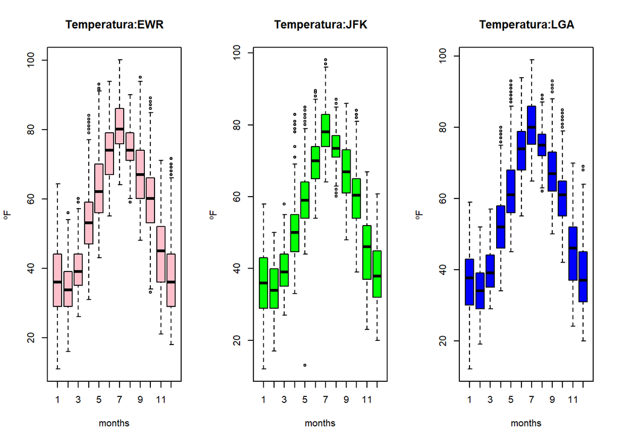

```r
JFK <- weather[weather$origin == "JFK",]
LGA <- weather[weather$origin == "LGA",]
EWR <- weather[weather$origin == "EWR",]

par(mfrow = c(1,3))
boxplot(EWR$temp ~ EWR$month,
        col = "pink",
        ylab = "ºF",
        xlab = "months",
        main = "Temperatura:EWR",)
boxplot(JFK$temp ~ JFK$month,
        col = "green",
        ylab = "ºF",
        xlab = "months",
        main = "Temperatura:JFK",)
boxplot(LGA$temp ~ LGA$month,
        col = "blue",
        ylab = "ºF",
        xlab = "months",
        main = "Temperatura:LGA",)
```

3.b Crea funcion que plot lo anterior

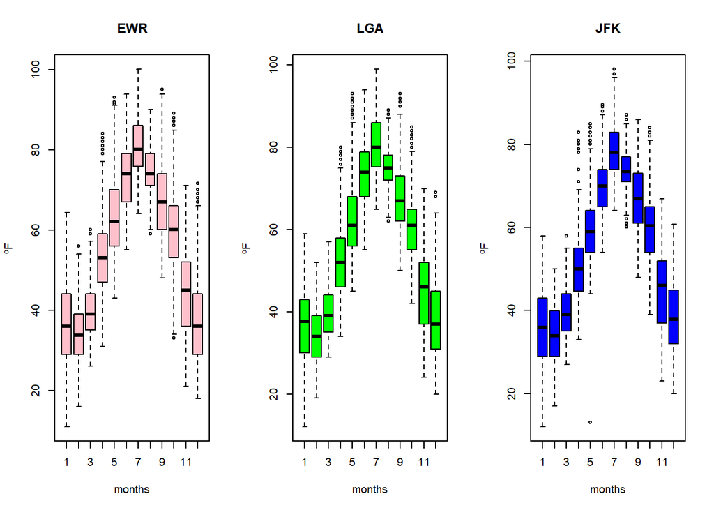

```r
plot_meteo <-function(data1,data2,data3, meteo1,meteo2,meteo3,titulo1, titulo2,titulo3,unidad)
{
  par(mfrow = c(1,3))
  boxplot(meteo1 ~ data1$month,col="pink", main = titulo1,xlab="months",ylab= unidad,)
  boxplot(meteo2 ~ data2$month,col="green", main = titulo2,xlab="months",ylab= unidad,)
  boxplot(meteo3 ~ data3$month,col="blue", main = titulo3,xlab="months",ylab= unidad,)
}
plot_meteo(EWR, LGA,JFK, EWR$temp, LGA$temp, JFK$temp, "EWR", "LGA", "JFK", "ºF")
```

### Ejercicio 4 - El dia de tu cumpleaños

4.a Correlacion temperatura y humedad en cada uno de los origenes

```r
dia_cumpleaños <- filter(weather, month == 3, day ==13)

cor <- cor(dia_cumpleaños$temp, dia_cumpleaños$humid)

print(paste0("Con un valor de ", cor, " podemos decir que hay una relación inversa entre la temperatura y la humedad en el día 13 de Marzo."))
```

```
## [1] "Con un valor de -0.853111659330045 podemos decir que hay una relación inversa entre la temperatura y la humedad en el día 13 de Marzo."
```

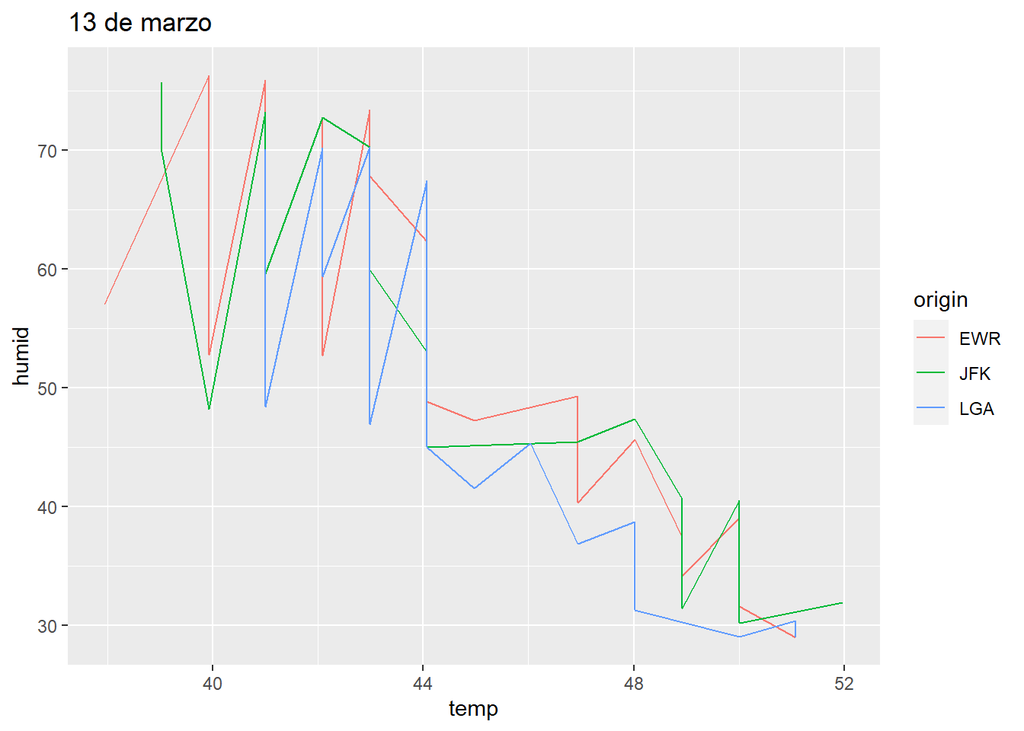

```r
ggplot(data= dia_cumpleaños)+
  geom_line(mapping = aes(temp, humid, col= origin))+
  ggtitle("13 de marzo")
```

### Ejercicio 6

Sube el examen a github y escribe a continuación tu url aquí.